# hierarchial

Hierarchical Clustering: Description, Advantages, and Disadvantages Description of Hierarchical Clustering: Hierarchical clustering is an unsupervised learning algorithm used to group similar data points into clusters. It works by creating a hierarchy of clusters, where each data point starts in its own cluster, and pairs of clusters are merged as the hierarchy progresses. This type of clustering does not require the number of clusters to be specified in advance, unlike K-Means clustering.

There are two types of hierarchical clustering:

Agglomerative (Bottom-Up Approach): In this approach, each data point starts as its own cluster. The algorithm iteratively merges the two closest clusters until all data points are part of a single cluster. Divisive (Top-Down Approach): In this approach, all data points start in one cluster, and the algorithm repeatedly splits the clusters into smaller ones. For this project, the Agglomerative Hierarchical Clustering will be used to group customers based on their demographic details, annual income, and spending scores. The output of hierarchical clustering is typically represented using a dendrogram, which shows the arrangement of clusters and how they are merged at each step.

Steps Involved in Hierarchical Clustering: Feature Encoding and Scaling:

Before applying hierarchical clustering, categorical features are encoded, and numerical features are standardized (scaled) so that they are comparable and not biased by different scales. Distance Metric:

The algorithm uses a distance metric, typically Euclidean distance, to calculate the distance between data points or clusters. The most common linkage methods used to calculate the distance between clusters are: Single Linkage: Distance between the closest points in two clusters. Complete Linkage: Distance between the furthest points in two clusters. Average Linkage: Average distance between all points in two clusters. Ward Linkage: Minimizes the variance within each cluster. Dendrogram Construction:

The dendrogram is a tree-like diagram that shows how clusters are formed by successive merging (in agglomerative clustering) or splitting (in divisive clustering). The dendrogram helps visualize the number of clusters to choose by looking for the largest vertical distance between merges. Model Training and Prediction:

The hierarchical clustering algorithm does not require training like supervised models. Instead, it involves constructing the hierarchy and deciding on a cut-off distance to decide the number of clusters. Performance Metrics:

While there is no single, universal metric for evaluating hierarchical clustering, silhouette score, calinski-harabasz index, and davies-bouldin index can be used to evaluate the quality of the clusters formed. Formulae Used in Hierarchical Clustering: Euclidean Distance (for calculating the distance between data points):

Where:

Where:

Unlike K-Means clustering, hierarchical clustering does not require the user to specify the number of clusters beforehand. The number of clusters can be determined from the dendrogram. Easy to Understand:

The concept of hierarchical clustering is intuitive, especially with the dendrogram, which provides a clear view of how clusters are formed. Flexibility in Cluster Shape:

Hierarchical clustering can handle clusters of arbitrary shapes, unlike K-Means which assumes spherical clusters. Suitable for Small Datasets:

Hierarchical clustering works well for small datasets and when the relationship between data points needs to be understood at different levels of granularity. No Assumptions about Data Distribution:

Unlike K-Means, which assumes that clusters have similar sizes and densities, hierarchical clustering is more flexible and doesn't require such assumptions. Disadvantages of Hierarchical Clustering: Computational Complexity:

Hierarchical clustering can be sensitive to noise and outliers, as these points can affect the distance calculations and the overall clustering process. Difficult to Scale:

While hierarchical clustering is effective for small datasets, it becomes inefficient and slow for large datasets because of its quadratic time complexity. Once a Merge or Split is Done, It Cannot Be Reversed:

In agglomerative clustering, once two clusters are merged, they cannot be unmerged. This can be a limitation if the algorithm makes an incorrect merge early on. Cluster Shape Assumptions:

Although hierarchical clustering can form arbitrarily shaped clusters, the choice of distance metric and linkage method can affect the outcome, and poor choices may lead to suboptimal clusters. When to Use Hierarchical Clustering: When the number of clusters is not known in advance and needs to be determined dynamically from the data. For datasets with relatively small to medium sizes where the hierarchical structure of data is meaningful. When the goal is to produce a dendrogram to visually represent the hierarchy of data points and their relationships. When computational resources are available to handle the higher time complexity of the algorithm. Use Case in the Project: In the project involving customer segmentation, hierarchical clustering will be used to group customers based on their spending behavior and demographic features (such as age, income, and spending score). By analyzing the dendrogram, we can visualize and decide on the appropriate number of customer segments, which can help in creating personalized marketing strategies, optimizing customer experiences, and boosting sales in the retail industry.

```
   CustomerID  Gender  Age  Annual Income (k$)  Spending Score (1-100)
0           1    Male   19                  15                      39
1           2    Male   21                  15                      81
2           3  Female   20                  16                       6
3           4  Female   23                  16                      77
4           5  Female   31                  17                      40
```

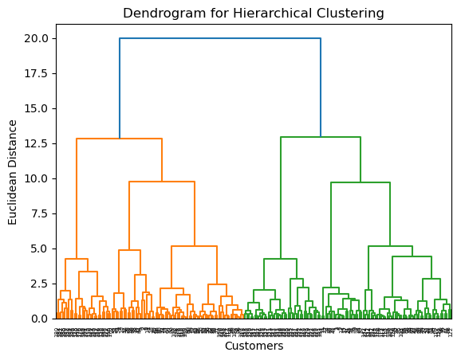

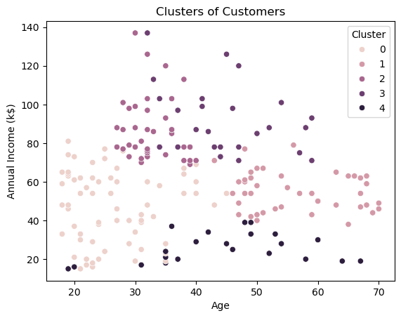

```
Silhouette Score: 0.3900
```

```python
import pandas as pd
import numpy as np
import matplotlib.pyplot as plt
import seaborn as sns
from sklearn.preprocessing import StandardScaler
from sklearn.cluster import AgglomerativeClustering
from scipy.cluster.hierarchy import dendrogram, linkage
from sklearn.metrics import silhouette_score
df = pd.read_csv('Mall_Customers.csv')
print(df.head())
X = df[['Age', 'Annual Income (k$)', 'Spending Score (1-100)']]
scaler = StandardScaler()
X_scaled = scaler.fit_transform(X)
hc = AgglomerativeClustering(n_clusters=5, linkage='ward')
y_hc = hc.fit_predict(X_scaled)
df['Cluster'] = y_hc
linked = linkage(X_scaled, method='ward')
dendrogram(linked)
plt.title('Dendrogram for Hierarchical Clustering')
plt.xlabel('Customers')
plt.ylabel('Euclidean Distance')
plt.show()

sns.scatterplot(x=df['Age'], y=df['Annual Income (k$)'], hue=df['Cluster'])
plt.title('Clusters of Customers')
plt.xlabel('Age')
plt.ylabel('Annual Income (k$)')
plt.legend(title='Cluster')
plt.show()
sil_score = silhouette_score(X_scaled, y_hc)
print(f'Silhouette Score: {sil_score:.4f}')
```